# UDproject3

```python
import pandas as pd
import numpy as np
import matplotlib.pyplot as plt
import seaborn as sb
```

part 1 ) Exploratory data analysis step 1 ) extract the data

- read the data from csv
- convert the dataset into pandas dataframe
- explore the dataframe using df.ino(),df.head(),df.describe()

```python
df = pd.read_csv('dataset.csv', low_memory=False)
```

```python
df.info()
```

```
<class 'pandas.core.frame.DataFrame'>
RangeIndex: 2252058 entries, 0 to 2252057
Data columns (total 18 columns):
 #   Column                   Dtype
---  ------                   -----
 0   Unnamed: 0               int64
 1   Unnamed: 0.1             float64
 2   duration_sec             int64
 3   start_time               object
 4   end_time                 object
 5   start_station_id         float64
 6   start_station_name       object
 7   start_station_latitude   float64
 8   start_station_longitude  float64
 9   end_station_id           float64
 10  end_station_name         object
 11  end_station_latitude     float64
 12  end_station_longitude    float64
 13  bike_id                  int64
 14  user_type                object
 15  member_birth_year        float64
 16  member_gender            object
 17  bike_share_for_all_trip  object
dtypes: float64(8), int64(3), object(7)
memory usage: 309.3+ MB
```

```python
df.head()
```

|  | Unnamed: 0 | Unnamed: 0.1 | duration_sec | start_time | end_time | start_station_id | start_station_name | start_station_latitude | start_station_longitude | end_station_id | end_station_name | end_station_latitude | end_station_longitude | bike_id | user_type | member_birth_year | member_gender | bike_share_for_all_trip |
| --- | --- | --- | --- | --- | --- | --- | --- | --- | --- | --- | --- | --- | --- | --- | --- | --- | --- | --- |
| 0 | 0 | 0.0 | 80110 | 2017-12-31 16:57:39.6540 | 2018-01-01 15:12:50.2450 | 74.0 | Laguna St at Hayes St | 37.776435 | -122.426244 | 43.0 | San Francisco Public Library (Grove St at Hyde... | 37.778768 | -122.415929 | 96 | Customer | 1987.0 | Male | NaN |
| 1 | 1 | 1.0 | 78800 | 2017-12-31 15:56:34.8420 | 2018-01-01 13:49:55.6170 | 284.0 | Yerba Buena Center for the Arts (Howard St at ... | 37.784872 | -122.400876 | 96.0 | Dolores St at 15th St | 37.766210 | -122.426614 | 88 | Customer | 1965.0 | Female | NaN |
| 2 | 2 | 2.0 | 45768 | 2017-12-31 22:45:48.4110 | 2018-01-01 11:28:36.8830 | 245.0 | Downtown Berkeley BART | 37.870348 | -122.267764 | 245.0 | Downtown Berkeley BART | 37.870348 | -122.267764 | 1094 | Customer | NaN | NaN | NaN |
| 3 | 3 | 3.0 | 62172 | 2017-12-31 17:31:10.6360 | 2018-01-01 10:47:23.5310 | 60.0 | 8th St at Ringold St | 37.774520 | -122.409449 | 5.0 | Powell St BART Station (Market St at 5th St) | 37.783899 | -122.408445 | 2831 | Customer | NaN | NaN | NaN |
| 4 | 4 | 4.0 | 43603 | 2017-12-31 14:23:14.0010 | 2018-01-01 02:29:57.5710 | 239.0 | Bancroft Way at Telegraph Ave | 37.868813 | -122.258764 | 247.0 | Fulton St at Bancroft Way | 37.867789 | -122.265896 | 3167 | Subscriber | 1997.0 | Female | NaN |

The dataframe consists of 2252058 entries and total 18 columns

```python
#dataframe summary statistics
df.describe()
```

|  | Unnamed: 0 | Unnamed: 0.1 | duration_sec | start_station_id | start_station_latitude | start_station_longitude | end_station_id | end_station_latitude | end_station_longitude | bike_id | member_birth_year |
| --- | --- | --- | --- | --- | --- | --- | --- | --- | --- | --- | --- |
| count | 2.252058e+06 | 519700.000000 | 2.252058e+06 | 2.240479e+06 | 2.252058e+06 | 2.252058e+06 | 2.240479e+06 | 2.252058e+06 | 2.252058e+06 | 2.252058e+06 | 2.079810e+06 |
| mean | 1.244267e+05 | 259849.500000 | 9.181335e+02 | 1.132275e+02 | 3.776797e+01 | -1.223525e+02 | 1.114495e+02 | 3.776810e+01 | -1.223520e+02 | 2.101589e+03 | 1.982467e+03 |
| std | 1.133429e+05 | 150024.611786 | 2.686599e+03 | 9.713899e+01 | 1.015587e-01 | 1.560933e-01 | 9.702559e+01 | 1.014484e-01 | 1.556892e-01 | 1.195229e+03 | 1.051074e+01 |
| min | 0.000000e+00 | 0.000000 | 6.100000e+01 | 3.000000e+00 | 3.726331e+01 | -1.224737e+02 | 3.000000e+00 | 3.726331e+01 | -1.224737e+02 | 1.000000e+01 | 1.881000e+03 |
| 25% | 4.691700e+04 | 129924.750000 | 3.580000e+02 | 3.000000e+01 | 3.777143e+01 | -1.224114e+02 | 2.800000e+01 | 3.777166e+01 | -1.224094e+02 | 1.098000e+03 | 1.977000e+03 |
| 50% | 9.383500e+04 | 259849.500000 | 5.660000e+02 | 8.100000e+01 | 3.778127e+01 | -1.223974e+02 | 8.100000e+01 | 3.778175e+01 | -1.223971e+02 | 2.131000e+03 | 1.985000e+03 |
| 75% | 1.586908e+05 | 389774.250000 | 8.880000e+02 | 1.800000e+02 | 3.779539e+01 | -1.222948e+02 | 1.790000e+02 | 3.779539e+01 | -1.222948e+02 | 3.059000e+03 | 1.990000e+03 |
| max | 5.196990e+05 | 519699.000000 | 8.636900e+04 | 3.810000e+02 | 4.551000e+01 | -7.357000e+01 | 3.810000e+02 | 4.551000e+01 | -7.357000e+01 | 4.466000e+03 | 2.000000e+03 |

so we can see the main features in the data set are

- user_type
- member_gender
- member_birth_year
- start_station_name
- duration_sec

step 2 ) Handling Missing Data

```python
df.isna()
```

|  | Unnamed: 0 | Unnamed: 0.1 | duration_sec | start_time | end_time | start_station_id | start_station_name | start_station_latitude | start_station_longitude | end_station_id | end_station_name | end_station_latitude | end_station_longitude | bike_id | user_type | member_birth_year | member_gender | bike_share_for_all_trip |
| --- | --- | --- | --- | --- | --- | --- | --- | --- | --- | --- | --- | --- | --- | --- | --- | --- | --- | --- |
| 0 | False | False | False | False | False | False | False | False | False | False | False | False | False | False | False | False | False | True |
| 1 | False | False | False | False | False | False | False | False | False | False | False | False | False | False | False | False | False | True |
| 2 | False | False | False | False | False | False | False | False | False | False | False | False | False | False | False | True | True | True |
| 3 | False | False | False | False | False | False | False | False | False | False | False | False | False | False | False | True | True | True |
| 4 | False | False | False | False | False | False | False | False | False | False | False | False | False | False | False | False | False | True |
| ... | ... | ... | ... | ... | ... | ... | ... | ... | ... | ... | ... | ... | ... | ... | ... | ... | ... | ... |
| 2252053 | False | True | False | False | False | False | False | False | False | False | False | False | False | False | False | False | False | False |
| 2252054 | False | True | False | False | False | False | False | False | False | False | False | False | False | False | False | False | False | False |
| 2252055 | False | True | False | False | False | False | False | False | False | False | False | False | False | False | False | False | False | False |
| 2252056 | False | True | False | False | False | False | False | False | False | False | False | False | False | False | False | False | False | False |
| 2252057 | False | True | False | False | False | False | False | False | False | False | False | False | False | False | False | False | False | False |

2252058 rows × 18 columns

```python
df.isnull().sum()
```

```
Unnamed: 0                       0
Unnamed: 0.1               1732358
duration_sec                     0
start_time                       0
end_time                         0
start_station_id             11579
start_station_name           11579
start_station_latitude           0
start_station_longitude          0
end_station_id               11579
end_station_name             11579
end_station_latitude             0
end_station_longitude            0
bike_id                          0
user_type                        0
member_birth_year           172248
member_gender               171818
bike_share_for_all_trip     519700
dtype: int64
```

```python
df.duplicated().sum()
```

```
0
```

3) explore the main features ( columns )

```python
df['bike_id']
```

```
0            96
1            88
2          1094
3          2831
4          3167
           ...
2252053    1860
2252054    3028
2252055    3139
2252056    1321
2252057    2987
Name: bike_id, Length: 2252058, dtype: int64
```

```python
df['member_gender']
```

```
0            Male
1          Female
2             NaN
3             NaN
4          Female
            ...
2252053      Male
2252054      Male
2252055      Male
2252056      Male
2252057    Female
Name: member_gender, Length: 2252058, dtype: object
```

we can divide the member gender into 3 categories :

```
- Male
- Female
- missing value ( Nan ) - Other type
```

```python
df['member_birth_year']
```

```
0          1987.0
1          1965.0
2             NaN
3             NaN
4          1997.0
            ...
2252053    1970.0
2252054    1977.0
2252055    1990.0
2252056    1991.0
2252057    1984.0
Name: member_birth_year, Length: 2252058, dtype: float64
```

```python
df['members_age'] = 2020 - df['member_birth_year']
df['members_age']
```

```
0          33.0
1          55.0
2           NaN
3           NaN
4          23.0
           ...
2252053    50.0
2252054    43.0
2252055    30.0
2252056    29.0
2252057    36.0
Name: members_age, Length: 2252058, dtype: float64
```

```python
df['user_type']
```

```
0            Customer
1            Customer
2            Customer
3            Customer
4          Subscriber
              ...
2252053    Subscriber
2252054    Subscriber
2252055    Subscriber
2252056    Subscriber
2252057    Subscriber
Name: user_type, Length: 2252058, dtype: object
```

the main types of users are

- Customer
- Subscriber

```python
df['bike_share_for_all_trip']
```

```
0          NaN
1          NaN
2          NaN
3          NaN
4          NaN
          ...
2252053    Yes
2252054     No
2252055     No
2252056     No
2252057     No
Name: bike_share_for_all_trip, Length: 2252058, dtype: object
```

now i will explore the start and end stations names

```python
df['start_station_name'].unique()
```

```
array(['Laguna St at Hayes St',
       'Yerba Buena Center for the Arts (Howard St at 3rd St)',
       'Downtown Berkeley BART', '8th St at Ringold St',
       'Bancroft Way at Telegraph Ave',
       'San Francisco Caltrain (Townsend St at 4th St)',
       'Addison St at Fourth St',
       'Mechanics Monument Plaza (Market St at Bush St)',
       'San Francisco Caltrain Station 2  (Townsend St at 4th St)',
       '3rd St at Townsend St', 'Clay St at Battery St',
       'Folsom St at 9th St', 'Cyril Magnin St at Ellis St',
       'San Salvador St at 9th St',
       'Garfield Square (25th St at Harrison St)',
       'The Embarcadero at Sansome St', 'Broadway at Kearny',
       'S Park St at 3rd St', 'California St at University Ave',
       'Frank H Ogawa Plaza', 'Dolores St at 15th St',
       'The Alameda at Bush St', '19th Street BART Station',
       'Valencia St at 16th St', 'Post St at Kearny St',
       'San Francisco City Hall (Polk St at Grove St)',
       'Church St at Duboce Ave', '19th St at Florida St',
       'Russell St at College Ave', 'The Embarcadero at Vallejo St',
       '5th St at Howard St', 'Market St at 10th St',
       'Valencia St at 21st St', '24th St at Chattanooga St',
       '14th St at Mandela Pkwy', 'Beale St at Harrison St',
       'Mission Playground', 'Valencia St at 24th St',
       'Washington St at Kearny St', 'The Embarcadero at Steuart St',
       'Esprit Park', '18th St at Noe St', 'Washington St at 8th St',
       'Lake Merritt BART Station', 'Golden Gate Ave at Polk St',
       'The Embarcadero at Bryant St', 'Grove St at Divisadero',
       'Golden Gate Ave at Hyde St', '2nd St at S Park St',
       'Steuart St at Market St', 'Davis St at Jackson St',
       'Morrison Ave at Julian St', 'West Oakland BART Station',
       '29th St at Tiffany Ave', '20th St at Bryant St',
       'Valencia St at 22nd St', '2nd Ave at E 18th St',
       'College Ave at Harwood Ave', 'Cahill Park',
       'Folsom St at 15th St', 'Berry St at 4th St',
       'MLK Jr Way at 14th St', 'McAllister St at Baker St',
       'Market St at Dolores St', 'Howard St at 8th St',
       '45th St at Manila', '14th St at Mission St',
       '4th St at Mission Bay Blvd S', 'Telegraph Ave at 23rd St',
       'El Embarcadero at Grand Ave', '2nd St at Folsom St',
```

[output cut: 133 more lines]

```
       '23rd St at San Bruno Ave', 'Miles Ave at Cavour St',
       'Madison St at 17th St', '9th St at San Fernando St',
       'Webster St at MacArthur Blvd (Temporary Location)',
       '4th Ave at E 12th St (Temporary Location)',
       '6th Ave at E 12th St (Temporary Location)',
       'Lane St at Van Dyke Ave', 'Lane St at Revere Ave',
       'Williams Ave at Apollo St', 'Newhall St at 3rd St',
       'Mendell St at Fairfax Ave', 'Viva Calle SJ',
       'Jones St at Post St', 'Grove St at Masonic Ave',
       'Myrtle St at Polk St', 'Hyde St at Post St',
       'Potrero del Sol Park (25th St at Utah St)',
       'Lombard St at Columbus Ave', 'Empire St at 7th St',
       '20th St at Dolores St', 'Fell St at Stanyan St', 'Guerrero Park',
       'Williams Ave at 3rd St', 'Farnam St at Fruitvale Ave'],
      dtype=object)
```

```python
df['end_station_name'].unique()
```

```
array(['San Francisco Public Library (Grove St at Hyde St)',
       'Dolores St at 15th St', 'Downtown Berkeley BART',
       'Powell St BART Station (Market St at 5th St)',
       'Fulton St at Bancroft Way',
       'San Francisco Caltrain (Townsend St at 4th St)',
       'Addison St at Fourth St',
       'Yerba Buena Center for the Arts (Howard St at 3rd St)',
       'Mechanics Monument Plaza (Market St at Bush St)',
       'Howard St at Beale St', 'Spear St at Folsom St',
       'The Embarcadero at Steuart St', 'Beale St at Harrison St',
       'San Francisco Ferry Building (Harry Bridges Plaza)',
       'Folsom St at 19th St', '5th St at Virginia St',
       'The Embarcadero at Sansome St', 'Folsom St at 15th St',
       'Clay St at Battery St', 'Davis St at Jackson St',
       '14th St at Mandela Pkwy', 'Market St at Dolores St',
       'Santa Clara St at Almaden Blvd', 'Bay Pl at Vernon St',
       'Victoria Manalo Draves Park', 'Steuart St at Market St',
       'The Embarcadero at Vallejo St', 'Mission Dolores Park',
       'Valencia St at 24th St', 'College Ave at Taft Ave',
       'Montgomery St BART Station (Market St at 2nd St)',
       'Valencia St at 22nd St', 'Koshland Park',
       '30th St at San Jose Ave', 'Jersey St at Castro St',
       '24th St at Market St', '3rd St at Townsend St',
       '20th St at Bryant St', 'Valencia St at Cesar Chavez St',
       'McCoppin St at Valencia St',
       'Powell St BART Station (Market St at 4th St)',
       'Berry St at 4th St', 'Frank H Ogawa Plaza',
       'Lake Merritt BART Station', '7th St at Brannan St',
       'Lakeshore Ave at Trestle Glen Rd', 'Golden Gate Ave at Polk St',
       'McAllister St at Baker St', '19th St at Mission St',
       '2nd St at Folsom St', '11th St at Bryant St', 'Cahill Park',
       'MLK Jr Way at 14th St', '14th St at Mission St',
       'The Embarcadero at Bryant St',
       'San Francisco City Hall (Polk St at Grove St)',
       'El Embarcadero at Grand Ave', 'Shattuck Ave at Hearst Ave',
       'Embarcadero BART Station (Beale St at Market St)',
       'Morrison Ave at Julian St',
       'Garfield Square (25th St at Harrison St)', '11th St at Natoma St',
       'Esprit Park', 'Derby St at College Ave',
       'West Oakland BART Station', 'Washington St at 8th St',
```

[output cut: 134 more lines]

```
       'Outside Lands 2018 (Temporary Station)', 'Miles Ave at Cavour St',
       '6th Ave at E 12th St (Temporary Location)',
       'Lane St at Revere Ave', 'Madison St at 17th St',
       '23rd St at San Bruno Ave',
       '4th Ave at E 12th St (Temporary Location)',
       '9th St at San Fernando St', 'Williams Ave at Apollo St',
       'Lane St at Van Dyke Ave',
       'Webster St at MacArthur Blvd (Temporary Location)',
       'Newhall St at 3rd St', 'Mendell St at Fairfax Ave',
       'Viva Calle SJ', 'Myrtle St at Polk St', 'Grove St at Masonic Ave',
       'Hyde St at Post St', 'Lombard St at Columbus Ave',
       'Potrero del Sol Park (25th St at Utah St)', 'Jones St at Post St',
       'Empire St at 7th St', '20th St at Dolores St',
       'Fell St at Stanyan St', 'Guerrero Park', 'Williams Ave at 3rd St',
       'Farnam St at Fruitvale Ave'], dtype=object)
```

- the next step Extract month and year from the date column and put the values into new columns

```python
import datetime
df['start_year'] = pd.DatetimeIndex(df['start_time']).year
df['start_month'] = pd.DatetimeIndex(df['start_time']).month

df.head()
```

|  | Unnamed: 0 | Unnamed: 0.1 | duration_sec | start_time | end_time | start_station_id | start_station_name | start_station_latitude | start_station_longitude | end_station_id | ... | end_station_latitude | end_station_longitude | bike_id | user_type | member_birth_year | member_gender | bike_share_for_all_trip | members_age | start_year | start_month |
| --- | --- | --- | --- | --- | --- | --- | --- | --- | --- | --- | --- | --- | --- | --- | --- | --- | --- | --- | --- | --- | --- |
| 0 | 0 | 0.0 | 80110 | 2017-12-31 16:57:39.6540 | 2018-01-01 15:12:50.2450 | 74.0 | Laguna St at Hayes St | 37.776435 | -122.426244 | 43.0 | ... | 37.778768 | -122.415929 | 96 | Customer | 1987.0 | Male | NaN | 33.0 | 2017 | 12 |
| 1 | 1 | 1.0 | 78800 | 2017-12-31 15:56:34.8420 | 2018-01-01 13:49:55.6170 | 284.0 | Yerba Buena Center for the Arts (Howard St at ... | 37.784872 | -122.400876 | 96.0 | ... | 37.766210 | -122.426614 | 88 | Customer | 1965.0 | Female | NaN | 55.0 | 2017 | 12 |
| 2 | 2 | 2.0 | 45768 | 2017-12-31 22:45:48.4110 | 2018-01-01 11:28:36.8830 | 245.0 | Downtown Berkeley BART | 37.870348 | -122.267764 | 245.0 | ... | 37.870348 | -122.267764 | 1094 | Customer | NaN | NaN | NaN | NaN | 2017 | 12 |
| 3 | 3 | 3.0 | 62172 | 2017-12-31 17:31:10.6360 | 2018-01-01 10:47:23.5310 | 60.0 | 8th St at Ringold St | 37.774520 | -122.409449 | 5.0 | ... | 37.783899 | -122.408445 | 2831 | Customer | NaN | NaN | NaN | NaN | 2017 | 12 |
| 4 | 4 | 4.0 | 43603 | 2017-12-31 14:23:14.0010 | 2018-01-01 02:29:57.5710 | 239.0 | Bancroft Way at Telegraph Ave | 37.868813 | -122.258764 | 247.0 | ... | 37.867789 | -122.265896 | 3167 | Subscriber | 1997.0 | Female | NaN | 23.0 | 2017 | 12 |

5 rows × 21 columns

```python
import datetime
df['end_year'] = pd.DatetimeIndex(df['end_time']).year
df['end_month'] = pd.DatetimeIndex(df['end_time']).month

df.head()
```

|  | Unnamed: 0 | Unnamed: 0.1 | duration_sec | start_time | end_time | start_station_id | start_station_name | start_station_latitude | start_station_longitude | end_station_id | ... | bike_id | user_type | member_birth_year | member_gender | bike_share_for_all_trip | members_age | start_year | start_month | end_year | end_month |
| --- | --- | --- | --- | --- | --- | --- | --- | --- | --- | --- | --- | --- | --- | --- | --- | --- | --- | --- | --- | --- | --- |
| 0 | 0 | 0.0 | 80110 | 2017-12-31 16:57:39.6540 | 2018-01-01 15:12:50.2450 | 74.0 | Laguna St at Hayes St | 37.776435 | -122.426244 | 43.0 | ... | 96 | Customer | 1987.0 | Male | NaN | 33.0 | 2017 | 12 | 2018 | 1 |
| 1 | 1 | 1.0 | 78800 | 2017-12-31 15:56:34.8420 | 2018-01-01 13:49:55.6170 | 284.0 | Yerba Buena Center for the Arts (Howard St at ... | 37.784872 | -122.400876 | 96.0 | ... | 88 | Customer | 1965.0 | Female | NaN | 55.0 | 2017 | 12 | 2018 | 1 |
| 2 | 2 | 2.0 | 45768 | 2017-12-31 22:45:48.4110 | 2018-01-01 11:28:36.8830 | 245.0 | Downtown Berkeley BART | 37.870348 | -122.267764 | 245.0 | ... | 1094 | Customer | NaN | NaN | NaN | NaN | 2017 | 12 | 2018 | 1 |
| 3 | 3 | 3.0 | 62172 | 2017-12-31 17:31:10.6360 | 2018-01-01 10:47:23.5310 | 60.0 | 8th St at Ringold St | 37.774520 | -122.409449 | 5.0 | ... | 2831 | Customer | NaN | NaN | NaN | NaN | 2017 | 12 | 2018 | 1 |
| 4 | 4 | 4.0 | 43603 | 2017-12-31 14:23:14.0010 | 2018-01-01 02:29:57.5710 | 239.0 | Bancroft Way at Telegraph Ave | 37.868813 | -122.258764 | 247.0 | ... | 3167 | Subscriber | 1997.0 | Female | NaN | 23.0 | 2017 | 12 | 2018 | 1 |

5 rows × 23 columns

step 3 ) Explore the dataset using visualizations

- univariate exploration
- using Bar Chart to show the freq of user_type

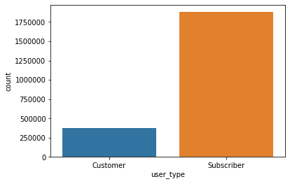

```python
import seaborn as sb
sb.countplot(data = df, x = 'user_type')
```

[output not shown]

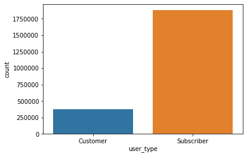

```python
import seaborn as sb
sb.countplot(data = df, x = 'user_type')
df.user_type.value_counts()
```

[output not shown]

As we've just seen, the subscriber type freq is higher than the customer type

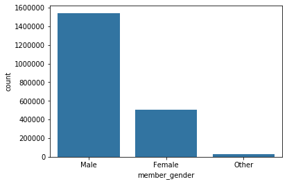

```python
base_color = sb.color_palette()[0]
member_gender = df['member_gender'].value_counts().index
sb.countplot(data = df, x = 'member_gender', color = base_color, order = member_gender)
```

```python
df.member_gender.value_counts()
```

```
Male      1541528
Female     507383
Other       31329
Name: member_gender, dtype: int64
```

As we've just seen, the male geneder freq is higher than the female and othertype Male 1541528 Female 507383

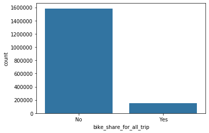

```python
#bike_share_for_all_trip
base_color = sb.color_palette()[0]
bike_share_for_all_trip = df['bike_share_for_all_trip'].value_counts().index
sb.countplot(data = df, x = 'bike_share_for_all_trip', color = base_color, order = bike_share_for_all_trip)
```

As we've just seen, most of the times there is no bike share for all trip

- visulaize the freq of the start and end months / years

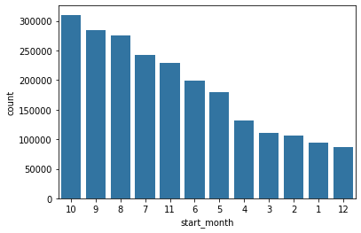

```python
#sort the fre of each month to extract the most frequant months
base_color = sb.color_palette()[0]
start_month = df['start_month'].value_counts().index
sb.countplot(data = df, x = 'start_month', color = base_color, order = start_month)
```

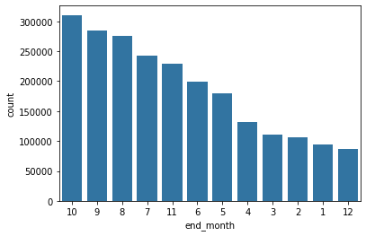

```python
base_color = sb.color_palette()[0]
end_month = df['end_month'].value_counts().index
sb.countplot(data = df, x = 'end_month', color = base_color, order = end_month)
```

October is the most freq month and decemeber is the lowest

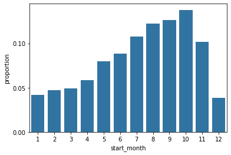

```python
# get proportion taken by most common group for derivation
n_points = df.shape[0]
max_count = df['start_month'].value_counts().max()
max_prop = max_count / n_points

# generate tick mark locations and names
tick_props = np.arange(0, max_prop, 0.05)
tick_names = ['{:0.2f}'.format(v) for v in tick_props]

# create the plot
base_color = sb.color_palette()[0]
sb.countplot(data = df, x = 'start_month', color = base_color)
plt.yticks(tick_props * n_points, tick_names)
plt.ylabel('proportion')
```

```python
df.info()
```

[output not shown]

[output cut: 16 more lines]

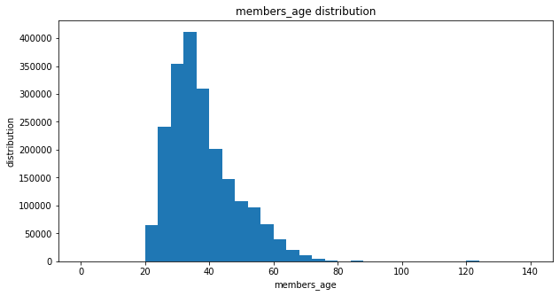

```python
#histogram for members_age to explore the distribution of members age
plt.figure(figsize=[10, 5])
bin_edges = np.arange(0, df['members_age'].max()+4, 4)
plt.hist(df['members_age'], bins=bin_edges)
plt.title('members_age distribution')
plt.xlabel("members_age")
plt.ylabel("distribution")
```

According to the histogram : most of the members age between 20 and 60 and few members have age above 60 to 80 years old

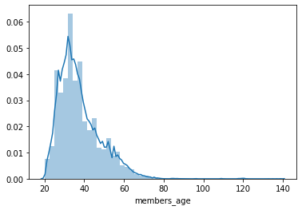

```python
sb.distplot(df['members_age'])
```

```python
df.info()
```

```
<class 'pandas.core.frame.DataFrame'>
RangeIndex: 2252058 entries, 0 to 2252057
Data columns (total 23 columns):
 #   Column                   Dtype
---  ------                   -----
 0   Unnamed: 0               int64
 1   Unnamed: 0.1             float64
 2   duration_sec             int64
 3   start_time               object
 4   end_time                 object
 5   start_station_id         float64
 6   start_station_name       object
 7   start_station_latitude   float64
 8   start_station_longitude  float64
 9   end_station_id           float64
 10  end_station_name         object
 11  end_station_latitude     float64
 12  end_station_longitude    float64
 13  bike_id                  int64
 14  user_type                object
 15  member_birth_year        float64
 16  member_gender            object
 17  bike_share_for_all_trip  object
 18  members_age              float64
 19  start_year               int64
 20  start_month              int64
 21  end_year                 int64
 22  end_month                int64
dtypes: float64(9), int64(7), object(7)
memory usage: 395.2+ MB
```

next step : Explore the aspects of the data like number of modes and skew and find the outliers in the data for further investigation.

```
(0, 40)
```

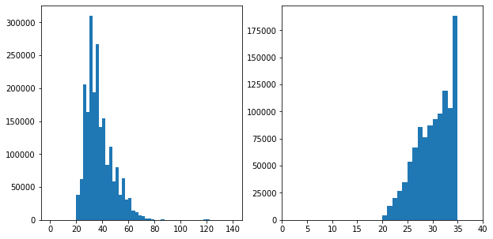

```python
# members_age histogram

plt.figure(figsize = [10, 5])
plt.subplot(1, 2, 1)
bin_edges = np.arange(0, df['members_age'].max()+2.5, 2.5)
plt.hist(data = df, x = 'members_age', bins = bin_edges)

plt.subplot(1, 2, 2)
bin_edges = np.arange(0, 35+1, 1)
plt.hist(data = df, x = 'members_age', bins = bin_edges)
plt.xlim(0, 40)
```

histogram on left: full data histogram on right: focus in on bulk of data < 35